# Between-dataset comparisons

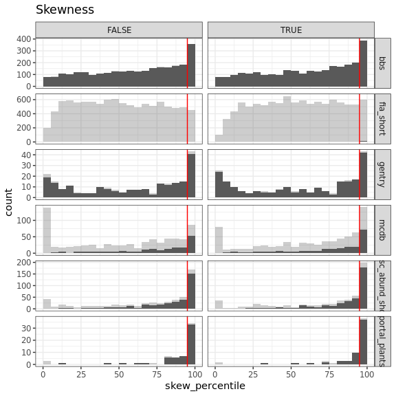

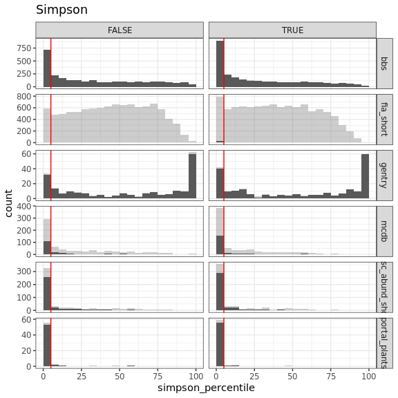

Observations from these histograms:

- FIA really struggles to get 2500 samples
- Portal is the *most* concentrated of all the datasets.
- Then MCDB and misc, then gentry, then bbs. FIA is hard to place but looks idiosyncratic.
- Curious about how variation in %ile maps on to S and N, *particularly* for Gentry and BBS.
- Skewness is less extreme than Simpson (more density in the in-between).
- Singletons doesn't appear to be terrifically impactful. From now on filtering to *unaltered* vectors.
- I think it's best to filter to at least 2000 samples.

Some summary statistics:

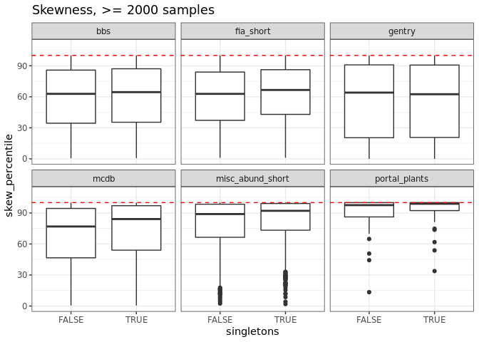

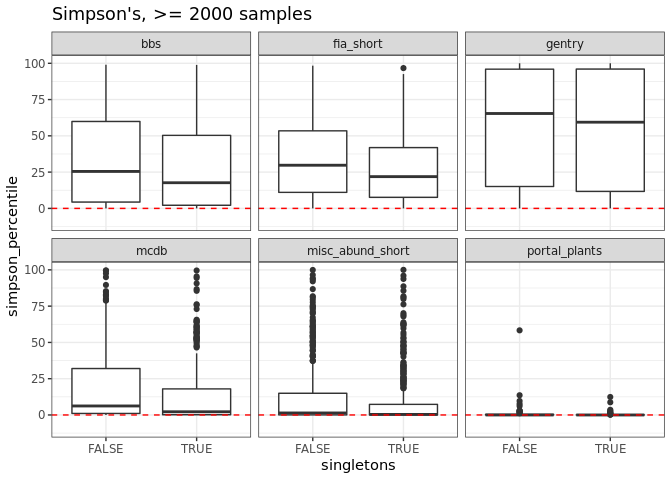

```
## # A tibble: 12 x 6
##    dat           singletons mean_nsamples nsites prop_skew_high prop_simpson_low
##    <chr>         <lgl>              <dbl>  <int>          <dbl>            <dbl>
##  1 bbs           FALSE              2500.   2772          0.130            0.261
##  2 bbs           TRUE               2500.   2772          0.141            0.323
##  3 fia_short     FALSE              2310.   2608          0.112            0.146
##  4 fia_short     TRUE               2326.   2946          0.127            0.192
##  5 gentry        FALSE              2497.    221          0.195            0.154
##  6 gentry        TRUE               2497.    222          0.194            0.189
##  7 mcdb          FALSE              2456.    324          0.238            0.469
##  8 mcdb          TRUE               2457.    371          0.302            0.606
##  9 misc_abund_s… FALSE              2487.    448          0.373            0.638
## 10 misc_abund_s… TRUE               2491.    453          0.430            0.704
## 11 portal_plants FALSE              2500.     58          0.569            0.914
## 12 portal_plants TRUE               2500.     59          0.644            0.966

## Warning: Using size for a discrete variable is not advised.

## Warning: Using size for a discrete variable is not advised.
```

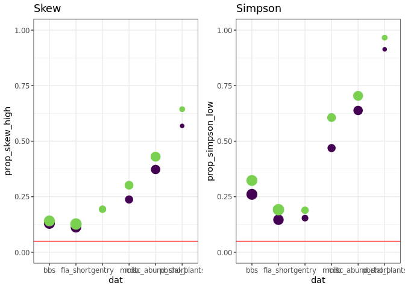

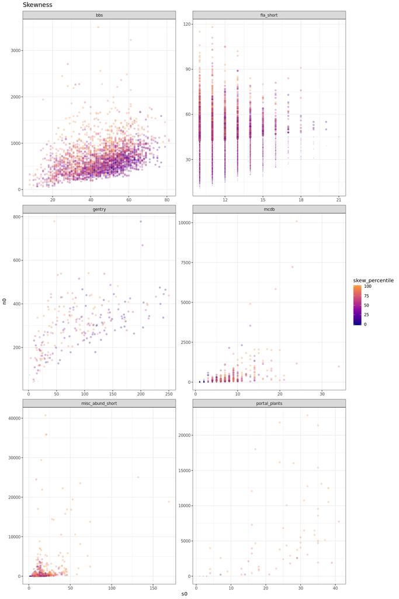

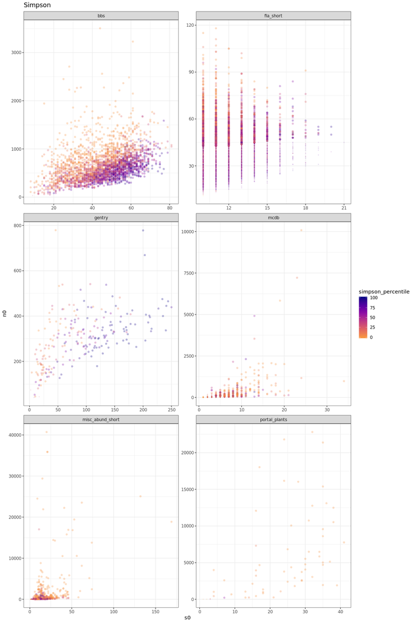

Conversely, for MCDB and Misc, it almost looks like the very least skewed elements are way down at tiny abundances?

Do percentiles scan with S/N?

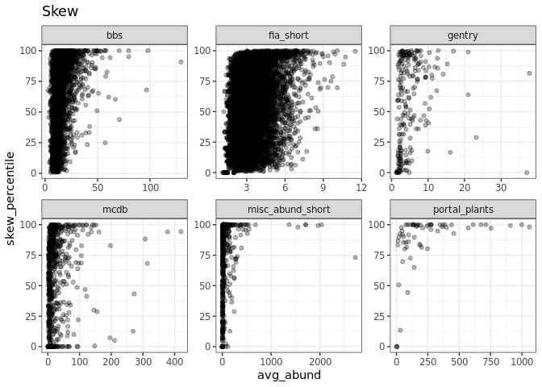

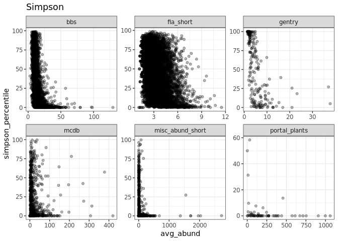

There is perhaps a constraint, but that might be because you rarely get v high average abundances. You seem to rarely get low skewness or high Simpson at high average abundance, which scans with the heatmaps.

Do Simpson and skewness correspond?

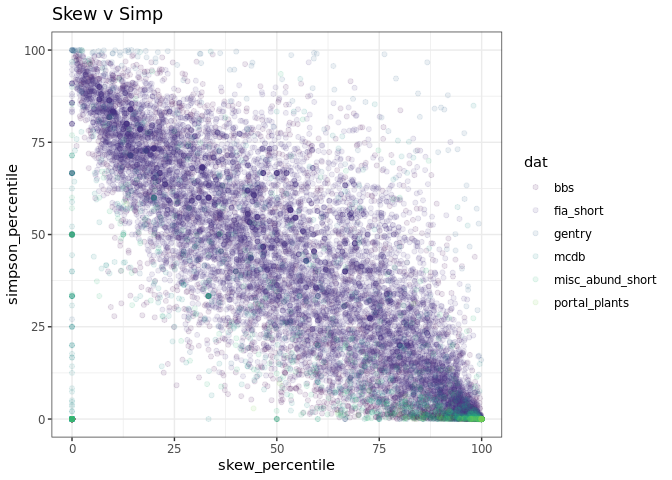

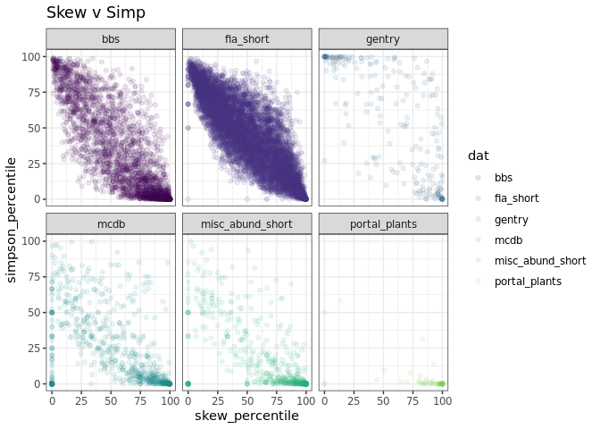

```
            Why is Gentry so strangely bimodal? It's like a U, when all the others tend towards one end or the other.
```

Why are BBS and mammals less frequently squished than Portal?

Looking at range of skewness and Simpsons:

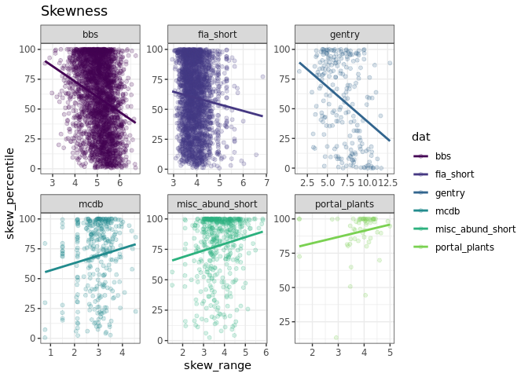

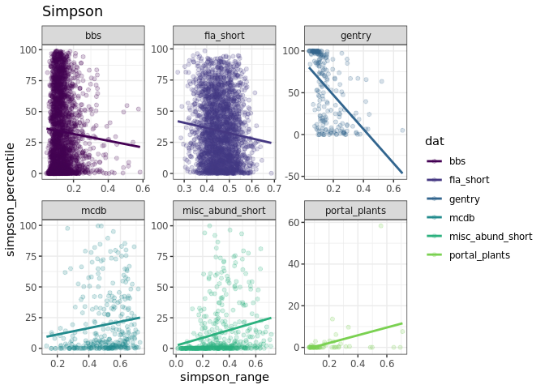

I added the ranges because I thought the percentiles might be constrained somewhat by the range of values represented in the feasible set. It doesn't look to me like there is a strong relationship between range and %ile.

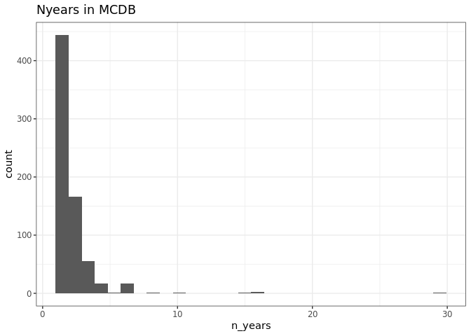

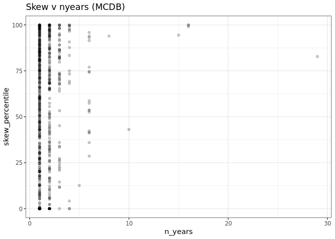

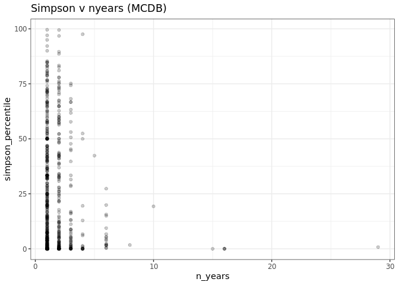